# DECDG

## Assessing access to sanitation facilities

#### Using World Bank's API, let's extract the data for improved sanitation facilities (% of population with access) indicator considering all time periods and skipping the aggregated data for now.

| Unnamed: 0 | Country | YR1960 | YR1961 | YR1962 | YR1963 | YR1964 | YR1965 | YR1966 | YR1967 | YR1968 | ... | YR2010 | YR2011 | YR2012 | YR2013 | YR2014 | YR2015 | YR2016 | YR2017 | YR2018 | YR2019 |
| --- | --- | --- | --- | --- | --- | --- | --- | --- | --- | --- | --- | --- | --- | --- | --- | --- | --- | --- | --- | --- | --- |
| AFG | Afghanistan | NaN | NaN | NaN | NaN | NaN | NaN | NaN | NaN | NaN | ... | 34.177028 | 35.457100 | 36.749962 | 38.055832 | 39.374932 | 40.707707 | 42.054183 | 43.417610 | NaN | NaN |
| ALB | Albania | NaN | NaN | NaN | NaN | NaN | NaN | NaN | NaN | NaN | ... | 95.571700 | 96.184770 | 96.776433 | 97.312548 | 97.676855 | 97.691034 | 97.704877 | 97.718368 | NaN | NaN |
| DZA | Algeria | NaN | NaN | NaN | NaN | NaN | NaN | NaN | NaN | NaN | ... | 86.560430 | 86.771741 | 86.970649 | 87.157454 | 87.332734 | 87.496717 | 87.542316 | 87.586571 | NaN | NaN |
| ASM | American Samoa | NaN | NaN | NaN | NaN | NaN | NaN | NaN | NaN | NaN | ... | 62.528187 | 61.374288 | 60.220573 | 59.067042 | 57.913695 | 56.760533 | 55.607554 | 54.454760 | NaN | NaN |
| AND | Andorra | NaN | NaN | NaN | NaN | NaN | NaN | NaN | NaN | NaN | ... | 99.999997 | 99.999995 | 100.000001 | 100.000000 | 99.999998 | 100.000002 | 100.000000 | 99.999996 | NaN | NaN |

5 rows × 61 columns

There are a number of NaN values in the datasets. This could be attritubed to the unavailibility of data for those years. To make this analysis more meaningful, we'll drop the columns where there are no valid values and interpolate for the years where we don't have data. From the metadata, we see that data is available only if more than 50% of the population is covered, so for any reason the data is not available for a particular year, we can interpolate the data based on its prior and subsequent years data.

Before starting the analysis, it is always good to understand the data, so let us read the metadata and understand what it is, how it is calculated and what some of the assumptions were.

World Bank's library has a neat function that allows you to display metadata within your notebook.

So from the metadata we know the indicator displays % of population for people using atleast basic sanitation services and is collected annually for countries.

#### Now, let us see what the relative percentage point difference is between the first year the data was collected and the most recent one to understand how % population using basic sanitation has changes over the years.

| Unnamed: 0 | Country | YR2000 | YR2001 | YR2002 | YR2003 | YR2004 | YR2005 | YR2006 | YR2007 | YR2008 | YR2009 | YR2010 | YR2011 | YR2012 | YR2013 | YR2014 | YR2015 | YR2016 | YR2017 | pct_chng |
| --- | --- | --- | --- | --- | --- | --- | --- | --- | --- | --- | --- | --- | --- | --- | --- | --- | --- | --- | --- | --- |
| VUT | Vanuatu | 61.816830 | 61.837027 | 61.857368 | 61.877994 | 61.898770 | 59.630144 | 57.387117 | 55.169509 | 52.977331 | 50.810512 | 48.652283 | 46.505765 | 44.380388 | 42.275959 | 40.192429 | 38.129741 | 36.088024 | 34.067058 | -27.749772 |
| GMB | Gambia, The | 57.650357 | 56.278596 | 54.933651 | 53.297984 | 51.729869 | 50.333408 | 48.988575 | 47.694239 | 46.449292 | 45.252495 | 44.102732 | 42.998717 | 41.939427 | 40.923138 | 39.948326 | 39.013416 | 39.122997 | 39.231150 | -18.419208 |
| ASM | American Samoa | 64.878105 | 64.872909 | 64.867713 | 64.862517 | 64.857321 | 64.852125 | 64.846929 | 64.841734 | 64.836538 | 63.682270 | 62.528187 | 61.374288 | 60.220573 | 59.067042 | 57.913695 | 56.760533 | 55.607554 | 54.454760 | -10.423344 |
| ZWE | Zimbabwe | 45.934149 | 46.053025 | 46.154841 | 46.106069 | 45.373752 | 44.645102 | 43.919848 | 43.198261 | 42.480092 | 41.765591 | 41.054527 | 40.347129 | 39.643185 | 38.942903 | 38.251461 | 37.568107 | 36.891731 | 36.221398 | -9.712752 |
| PNG | Papua New Guinea | 20.876527 | 20.866993 | 20.859190 | 20.851387 | 20.843152 | 20.224800 | 19.606526 | 18.988332 | 18.370216 | 17.763520 | 17.155589 | 16.546003 | 15.935597 | 15.329714 | 14.728244 | 14.131082 | 13.538123 | 12.949267 | -7.927260 |

#### Too see how this new metric is distributed, we'll create a histogram.

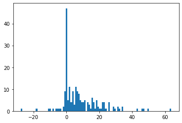

```
count    199.000000
mean       8.073017
std       11.719058
min      -27.749772
25%        0.002056
50%        5.266272
75%       13.566284
max       63.805300
Name: pct_chng, dtype: float64
```

#### But let us plot the data on a boxplot to identify the data points far away from from the mean of the distribution.

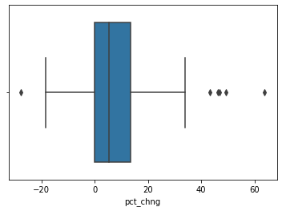

From the above we can see that there are infact a few outliers in the distribution. But what is more interesting is to see the number of countries where % population of people using basic sanitation services from 2000 to 2017 has fallen.

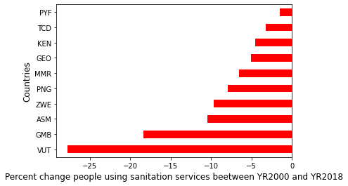

The graph above provides us with the differences for data points between the year 2000 and 2018 for the 10 countries with the hightest negative percentage point difference.

#### Let's now visualize how these numbers are changing over time.

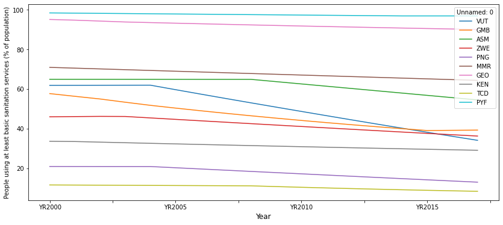

#### Now alternatively, let us now consider top 10 countries with the highest positive difference in percentage points between 2000 and 2018.

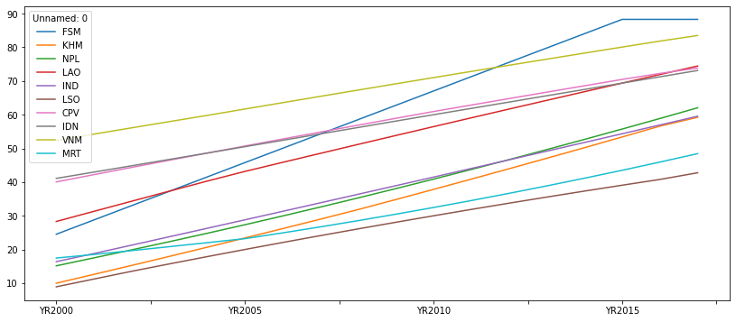

Federated States of Micronesia went up from about 25% in 2000 to over 85% in 2015. This could be the result of major interventions and shift of government's priorities to implement better sanitation facilities in order to minimize the health risks posed by open defecation and unsanitary practices. It also looks like most of these countries belong to low income and lower middle income countries.

#### Since it is less meaningful to plot all the data for 217 countries on one plot, let us group the data by income and see the temporal change (if any).

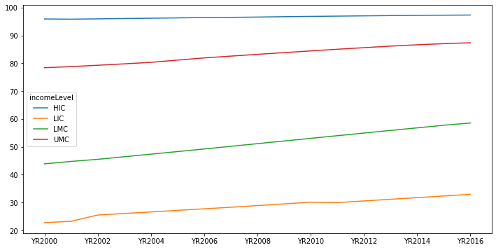

#### Since it's a global dataset, it would be helpful to see how countries are performing by leveraging a geospatial component.

```
CHI
```

We don't have boundary data for Channel Islands so you'll see one ISO3 code printed at the previous step. We now have a geodataframe with all the attributes returned by the API so we can merge this dataset with our sanitation facilities dataset.

#### Let's first see how world looked for percent population using basic sanitation facilities back in 2000.

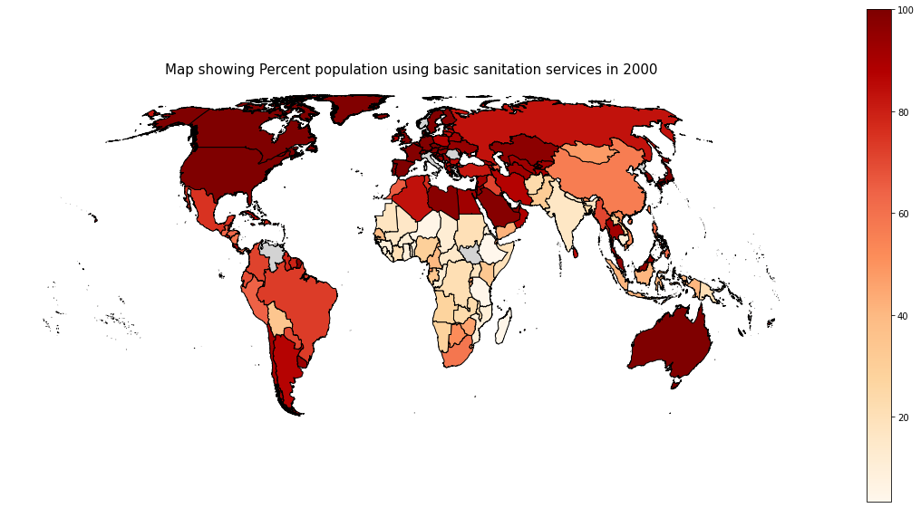

It is clear from the map that rich countries i.e. high income countries had close to 100% access to sanitation, for instance USA, Canada, Australia and most European countries. Whereas poorer countries in South Asia and Africa had poor access to these services (attributing to lighter color on the map).

#### Now's lets see how this indicator changed in 2017.

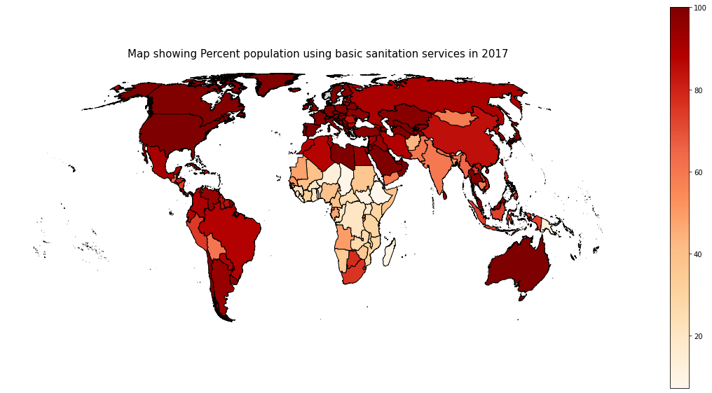

Compared to its predecessor, this map shows better use of sanitation services worldwide. It would be interesting to map more accurately the change that has happened in last two decades for more keen observation.

#### Below is the map depicting the difference in percentage points for sanitation services used by % population between 2000 and 2017 to help analyze the same.

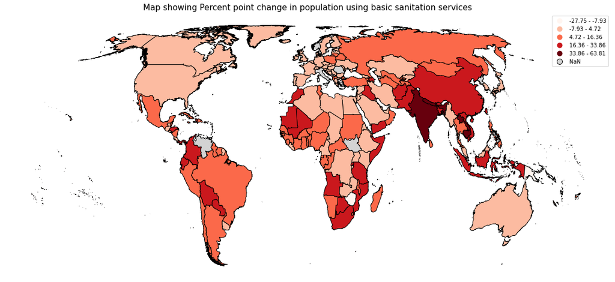

#### Stats for discussion note

| Unnamed: 0 | Country | YR2000 | YR2001 | YR2002 | YR2003 | YR2004 | YR2005 | YR2006 | YR2007 | YR2008 | YR2009 | YR2010 | YR2011 | YR2012 | YR2013 | YR2014 | YR2015 | YR2016 | YR2017 |
| --- | --- | --- | --- | --- | --- | --- | --- | --- | --- | --- | --- | --- | --- | --- | --- | --- | --- | --- | --- |
| ARB | Arab World | 73.638255 | 73.885097 | 74.195230 | 74.617211 | 75.067053 | 75.732633 | 76.433768 | 77.113932 | 77.849458 | 78.566938 | 79.260100 | 79.929621 | 80.571656 | 81.206259 | 81.782225 | 82.350001 | 82.841765 | 83.112235 |
| CSS | Caribbean small states | 83.305744 | 83.593149 | 83.880055 | 84.166275 | 84.568008 | 84.967152 | 85.366379 | 85.765831 | 86.165285 | 86.564416 | 86.957706 | 87.339321 | 87.708425 | 88.062094 | 88.321349 | 88.594837 | 88.959326 | 89.011299 |
| CEB | Central Europe and the Baltics | 91.477402 | 88.341575 | 88.653632 | 88.941748 | 89.227417 | 89.518753 | 89.962536 | 90.432654 | 90.907369 | 91.357762 | 91.795104 | 92.231561 | 92.657838 | 93.079794 | 93.502914 | 93.935563 | 94.373319 | 94.710774 |
| EAR | Early-demographic dividend | 38.077780 | 39.614381 | 41.216447 | 42.832369 | 44.452188 | 46.533031 | 48.146709 | 49.786735 | 51.430795 | 53.076989 | 54.722050 | 56.365781 | 58.002968 | 59.633717 | 61.251875 | 62.850422 | 64.433337 | 65.609959 |
| EAS | East Asia & Pacific | 60.760444 | 61.448321 | 63.136313 | 64.655995 | 66.151161 | 67.622098 | 69.067199 | 70.522746 | 71.957086 | 73.365208 | 74.750013 | 76.100594 | 77.426527 | 78.787524 | 80.129967 | 81.451923 | 82.753485 | 84.025783 |

| Unnamed: 0 | Country | pct_chng |
| --- | --- | --- |
| TSA | South Asia (IDA & IBRD) | 38.946788 |
| SAS | South Asia | 38.946788 |
| EAR | Early-demographic dividend | 27.532179 |
| EAP | East Asia & Pacific (excluding high income) | 26.121643 |
| TEA | East Asia & Pacific (IDA & IBRD countries) | 26.112159 |

```
Country          India
YR2000         16.3692
YR2001         18.7809
YR2002         21.2677
YR2003         23.7636
YR2004         26.2687
YR2005          28.782
YR2006         31.3034
YR2007         33.8332
YR2008          36.371
YR2009         38.9158
YR2010         41.4676
YR2011         44.0265
YR2012         46.5946
YR2013         49.1708
YR2014         51.7546
YR2015         54.3451
YR2016         56.9417
YR2017         59.5434
pct_chng       43.1742
incomeLevel        LMC
Name: IND, dtype: object
```

### Discussion

The data under consideration, gives the percent population having access to basic sanitation facilities that include flush/pour flush to piped sewer systems, septic tanks or pit latrines; ventilated improved pit latrines, compositing toilets or pit latrines with slabs. From figure 6 and figure 7 we can visually see the changes where these numbers have either increased or decreased. Access to sanitation is an important development indicator; poor sanitation can cause serious health issues thereby having cascading effects on a country's economy. Low income and low middle income country governments often don't have enough budget to build sophisticated medical infrastructure, and hence their best bet is to usually start from the ground up and work in areas where they can minimize the dramatic effects of illnesses. Having proper sanitation facilities at home can help avoid the transmission of diseases such as cholera, diarrhea, dysentery, hepatitis A, typhoid and polio and exacerbates stunting.[[Source]](https://www.who.int/news-room/fact-sheets/detail/sanitation)

In 2017, about 73.4\% of global population had access to basic sanitation facilities, an increase from 55.46\% in 2000 [goto]. The maximum change over this period of two decades can be seen in South Asia and other low middle income countries [goto]. Countries are classified as low income if the Gross National Income (GNI) per capita is less than \$1,025 low middle income if GNI per capita is between \\$1,026 and \$3,995 respectively[[Source]](https://datahelpdesk.worldbank.org/knowledgebase/articles/906519-world-bank-country-and-lending-groups). With over [20 countries](https://data.worldbank.org/indicator/NY.GNP.PCAP.CD?most_recent_value_desc=false) countries having GNI per capita less than \\$1000, it makes it very challenging for the government to create proper programs for sanitation. For instance, poor sanitation costs [Malawi](https://www.wsp.org/sites/wsp/files/publications/WSP-ESI-Malawi.pdf) (one of the lower ranking countries in GNI per capita list) about US $57 million for factors ranging from premature deaths to costs of healthcare, which in turn has cascading effects on country's economy.

India on the other hand went from 16\% in 2000 to about 60\% in 2017, an increase of 44\% point. New government implemented [sanitation programs](https://en.wikipedia.org/wiki/Swachh_Bharat_Mission#:~:text=A%20formal%20sanitation%20programme%20was,Nirmal%20Bharat%20Abhiyan%20in%202012.) like Total Sanitation Campaign in 1999, Nirmal Bharat Abhiyan in 2012 and Swachh Bharat Mission in 2014 have helped curb the open defecation issues in rural parts of India. These efforts also encourage the use of communal toilets in urban slums that is otherwise reponsible for major health hazard outbreaks. There have been multiple studies where lack of sanitation services have been linked with women safety. In one the [studies](https://bmcpublichealth.biomedcentral.com/articles/10.1186/s12889-019-6423-z), authors identified health impacts of open defecation, increased risk of secxual exploitation, threat to women's privacy and psychosocial stressors linked to open defecation.

In conclusion, the numbers show how far we've come to tackle the issue of sanitation and how local governments and international agencies are working in harmony to to eradicate the concept of open defecation. The issue of sanitation can be tied to multiple sustainable development goals such as health issue (SDG Goal 3), gender issue (SDG Goal 5) and sanitation issue (SDG Goal 6). With better and more accurate data at disposal, the policy makers can act efficiently and make actionable decisions.